# HR Analysis

2022-06-09

## First Steps

First we need to save the data in a computer-friendly format like CSV. Once the data is saved as a CSV file, we can read it into R. First we load a few packages that help with data wrangling, plotting, and statistical testing.

```r
library(tidyverse)
library(multcomp)
data <- read.csv('heart_rate_data.xlsx - Sheet1.csv')
```

## Data Wrangling

We will subset the CSV into 3 separate items - one for pre-stimulation, one for during stimulation, and one for post-stimulation. We also convert the data to be numeric for arithmetic operations.

```r
data_pre <- data[4:304,1:5] %>% sapply(., as.numeric) %>%
  as.tibble(.name_repair = "unique")

data_opto <- data[4:304, 11:15] %>% sapply(., as.numeric) %>%
  as.tibble(.name_repair = "unique")

data_post <- data[4:304, 21:25] %>% sapply(., as.numeric) %>%
  as.tibble(.name_repair = "unique")

print(head(data_pre))
```

```
## # A tibble: 6 × 5
##       X   X.1   X.2   X.3   X.4
##   <dbl> <dbl> <dbl> <dbl> <dbl>
## 1   222   275   347   293   299
## 2   223   275   342   293   300
## 3   220   275   338   291   301
## 4   218   273   332   296   295
## 5   220   274   337   297   302
## 6   220   274   332   301   300
```

## Summarizing the data

Now let’s average each mouse over the entire 5 minute period. We’ll add columns for group and mouse ID to track changes to the same mouse in different conditions.

```r
data_pre_avg <- colMeans(data_pre) %>% as.tibble()
data_pre_avg$group <- "pre"
data_pre_avg$id <- c(1:5)

data_opto_avg <- colMeans(data_opto) %>% as.tibble()
data_opto_avg$group <- "opto"
data_opto_avg$id <- c(1:5)

data_post_avg <- colMeans(data_post) %>% as.tibble()
data_post_avg$group <- "post"
data_post_avg$id <- c(1:5)

print(data_pre_avg)
```

```
## # A tibble: 5 × 3
##   value group    id
##   <dbl> <chr> <int>
## 1  208. pre       1
## 2  264. pre       2
## 3  330. pre       3
## 4  273. pre       4
## 5  276. pre       5
```

## Combining and Plotting

Now that the data are averaged, we can compare average HR during each condition. We combine the data into one dataframe for ease of plotting, and create a violin plot to show HR values for each group.

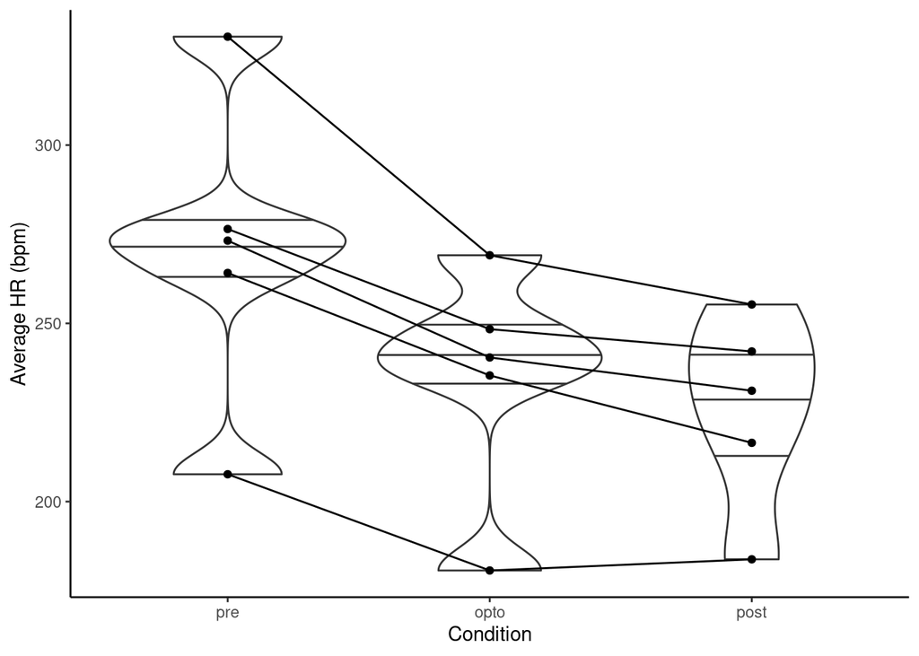

```r
combined_data <- rbind(data_pre_avg, data_opto_avg, data_post_avg)
combined_data$group <- factor(combined_data$group, levels = c("pre", "opto", "post"))

ggplot(combined_data, aes(x = group, y = value))+
  geom_violin(draw_quantiles = c(0.25, 0.5, 0.75))+
  geom_point()+
  geom_line(aes(group = id))+
  xlab("Condition")+
  ylab("Average HR (bpm)")+
  theme_classic()
```

## Test for significance

Since we have 3 groups, we can use an ANOVA with Tukey’s HSD for multiple comparisons.

```r
sig_test <- aov(value ~ group, combined_data) %>% TukeyHSD()
print(sig_test)
```

```
##   Tukey multiple comparisons of means
##     95% family-wise confidence level
##
## Fit: aov(formula = value ~ group, data = combined_data)
##
## $group
##                 diff        lwr      upr     p adj
## opto-pre  -35.584053  -95.15655 23.98845 0.2856962
## post-pre  -44.615947 -104.18845 14.95655 0.1550601
## post-opto  -9.031894  -68.60439 50.54061 0.9143947
```

From this, we can see that there is a trend towards decreased HR without a statistically significant change, as the p-value is ~0.15 between pre- and post- groups.